# SCENERY analysis – FDA

## 3.2 EDA $\sim$ speed + WST + noise

The formula for this functional linear model is of the form:

$$\text{EDA}_i(t) = \beta_0(t) +
\beta_1(t) \cdot \text{Speed}_i(t) +
\beta_2(t) \cdot \text{WST}_i(t) +
\beta_2(t) \cdot \text{Noise}_i(t) + \varepsilon_i(t).$$

Numerical characteristics for the model:

|  | $RMSE$ | Maximum $R^2$ | Integrated $R^2$ | $p$-value |
| --- | --- | --- | --- | --- |
| model characteristics | 0.9011355 | 0.6959741 | 20.08051 | 0.02 |

Observed and estimated outcome trajectories, graph of the functional $R^2$ and $F$-statistic:

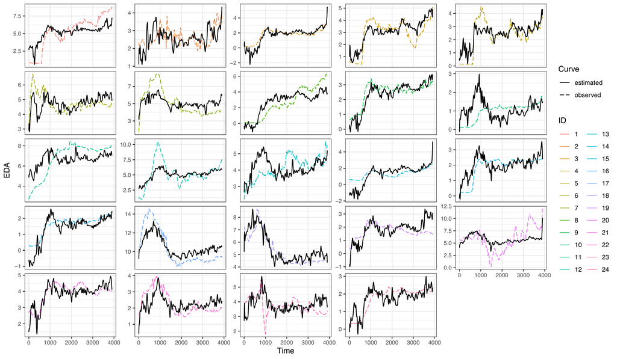

Observed and estimated trajectories.

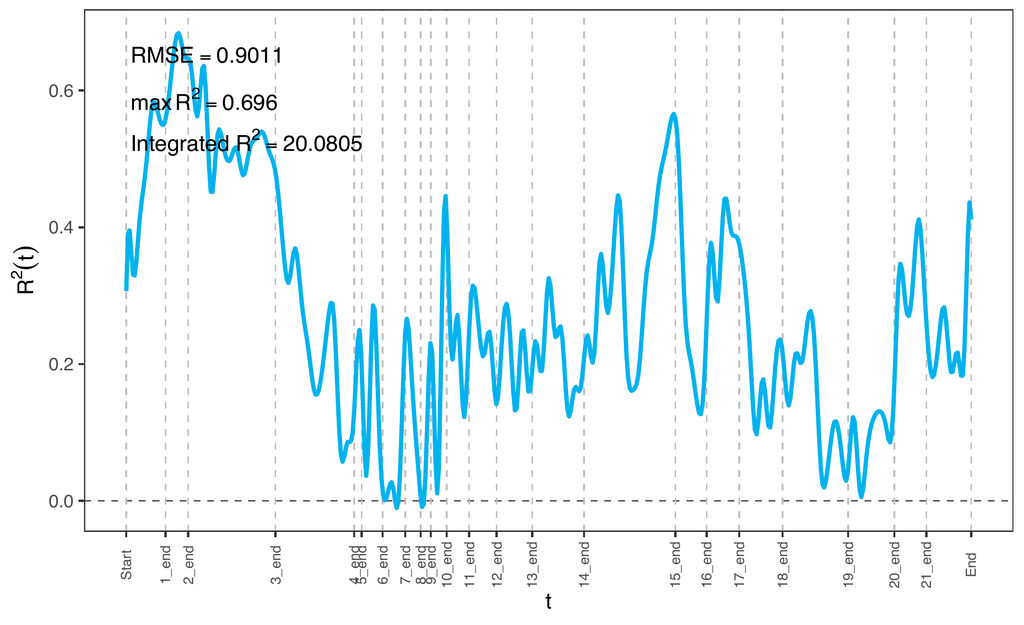

Graph of the functional $R^2$.

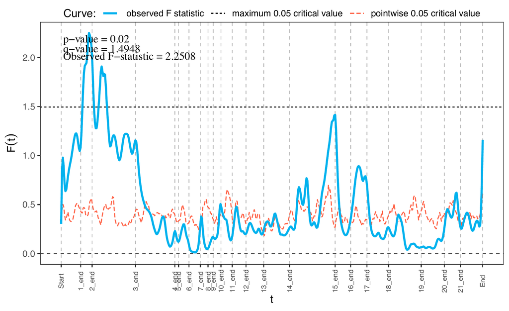

Graph of the functional $F$-statistic.

Finally, graphs of the estimated functional regression parameters $\widehat{\beta_j}(t), j = 1, 2, 3$ for intercept and covariates included in the model, with bootstrap CI and global envelope.

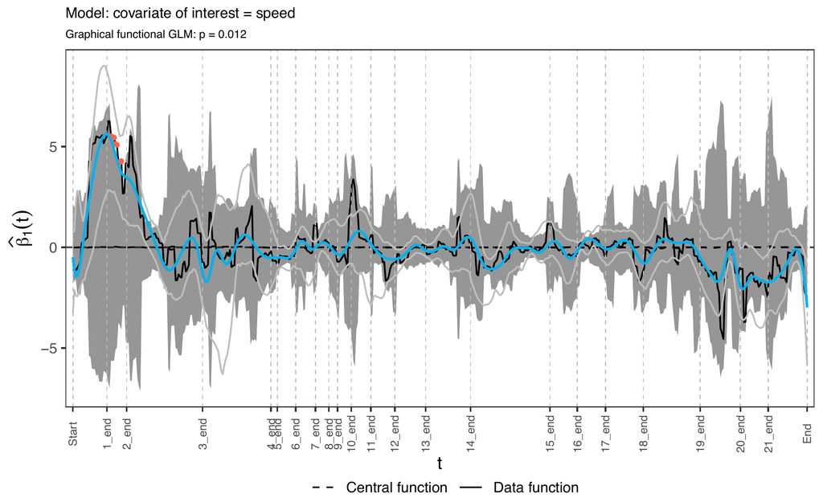

Graph for **Speed**

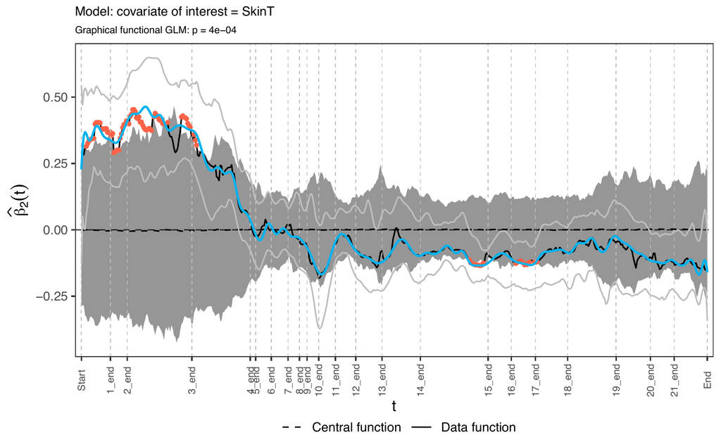

Graph for **WST**

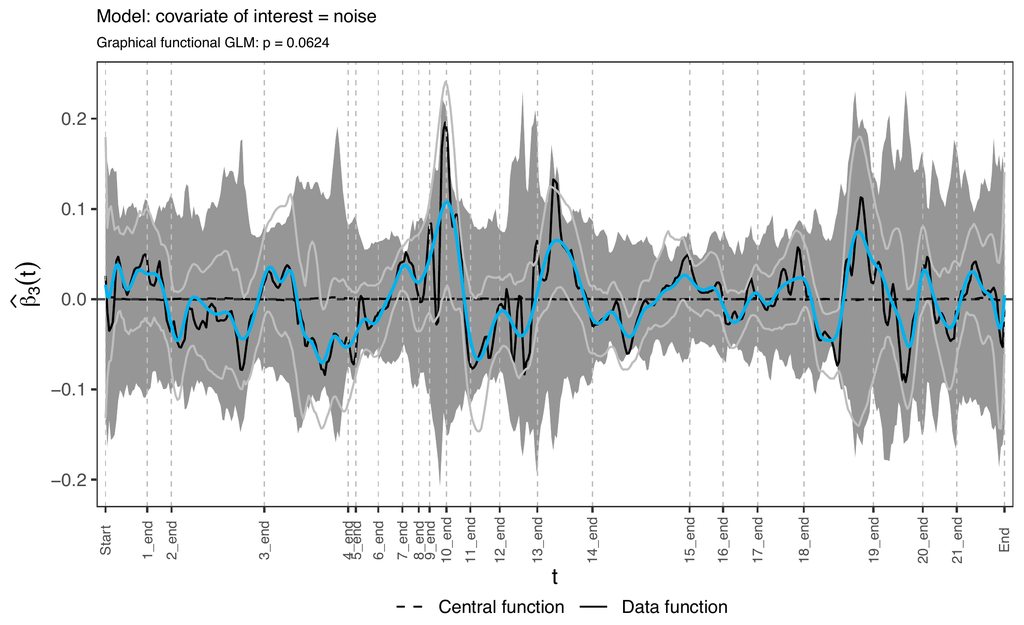

Graph for **Noise**

## 3.3 EDA $\sim$ slope + speed + WST + noise + Sex

The formula for this functional linear model is of the form:

$$\text{EDA}_i(t) = \beta_0(t) +
\beta_1(t) \cdot \text{Slope}_i(t) +
\beta_2(t) \cdot \text{Speed}_i(t) +
\beta_3(t) \cdot \text{WST}_i(t) +
\beta_4(t) \cdot \text{Noise}_i(t) +
\beta_5(t) \cdot \mathbb I\{\text{Sex}_i = "Male"\} + \varepsilon_i(t).$$

Numerical characteristics for the model:

|  | $RMSE$ | Maximum $R^2$ | Integrated $R^2$ | $p$-value |
| --- | --- | --- | --- | --- |
| model characteristics | 0.8721131 | 0.8044802 | 24.25159 | 0.045 |

Observed and estimated outcome trajectories, graph of the functional $R^2$ and $F$-statistic:

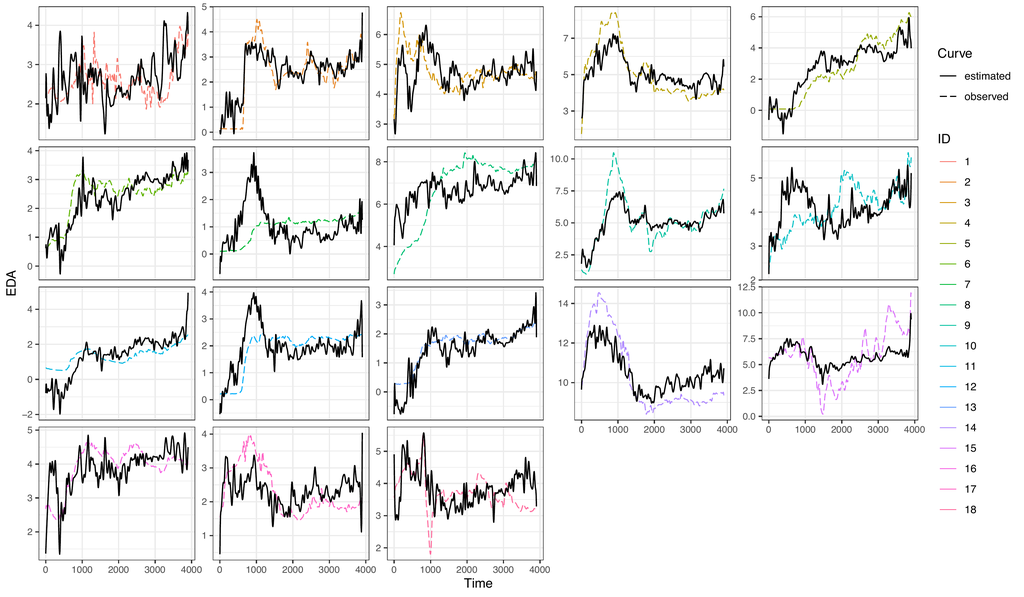

Observed and estimated trajectories.

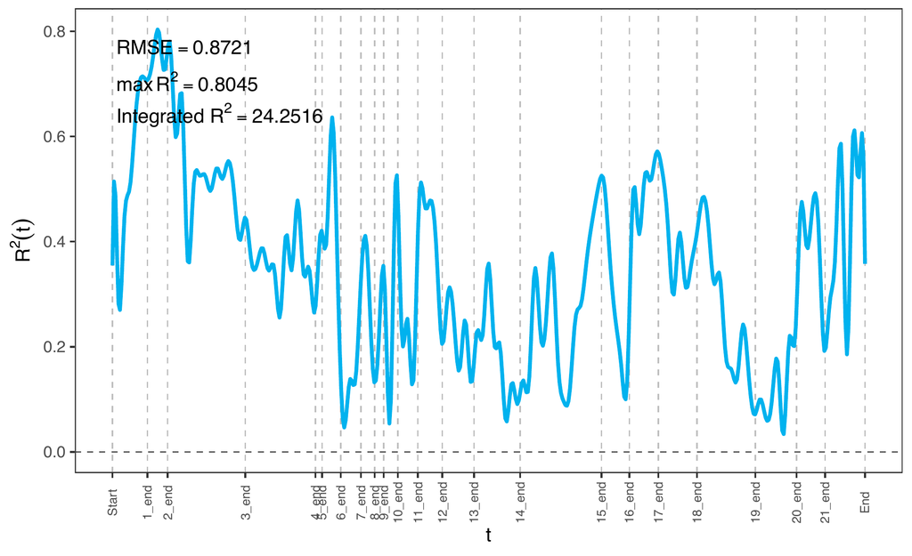

Graph of the functional $R^2$.

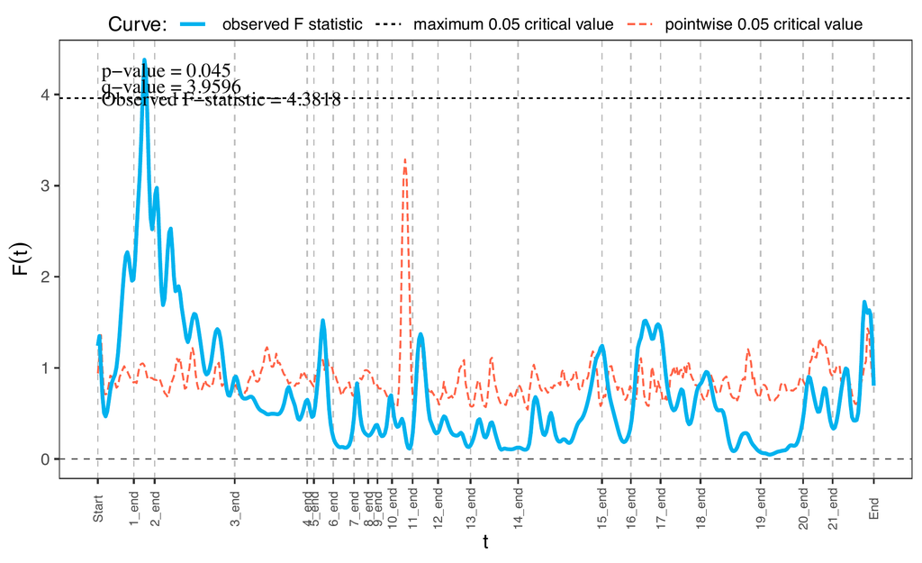

Graph of the functional $F$-statistic.

Finally, graphs of the estimated functional regression parameters $\widehat{\beta_j}(t), j = 1, 2, 3, 4, 5$ for intercept and covariates included in the model, with bootstrap CI and global envelope.

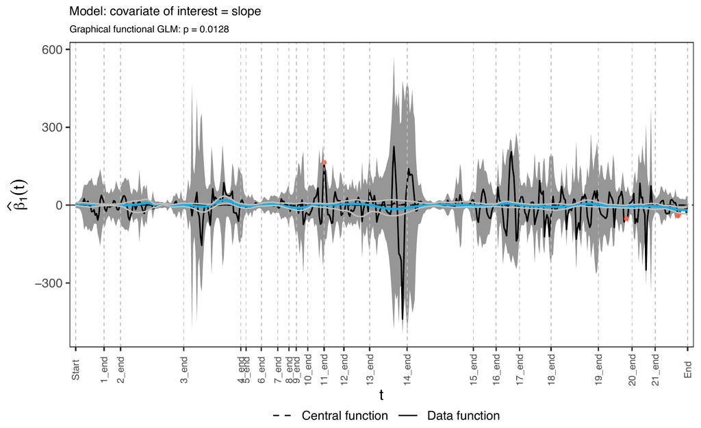

Graph for **Slope**

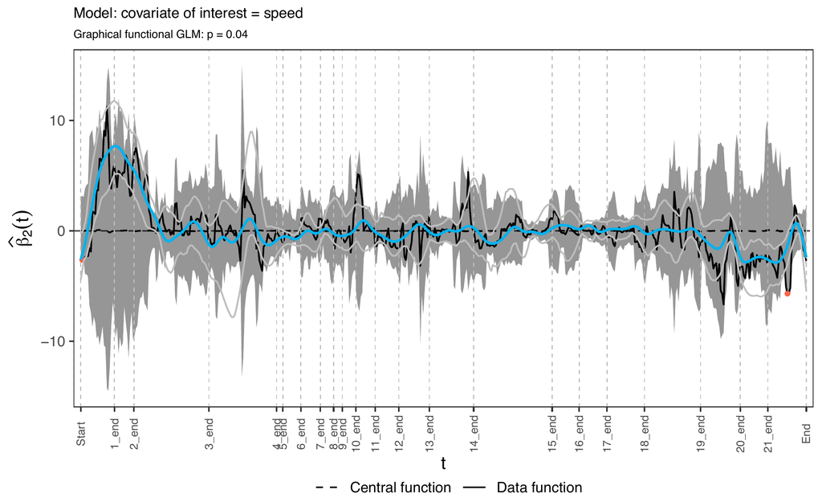

Graph for **Speed**

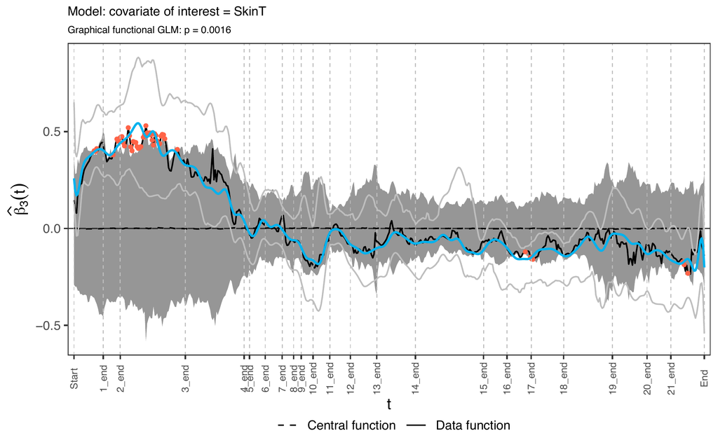

Graph for **WST**

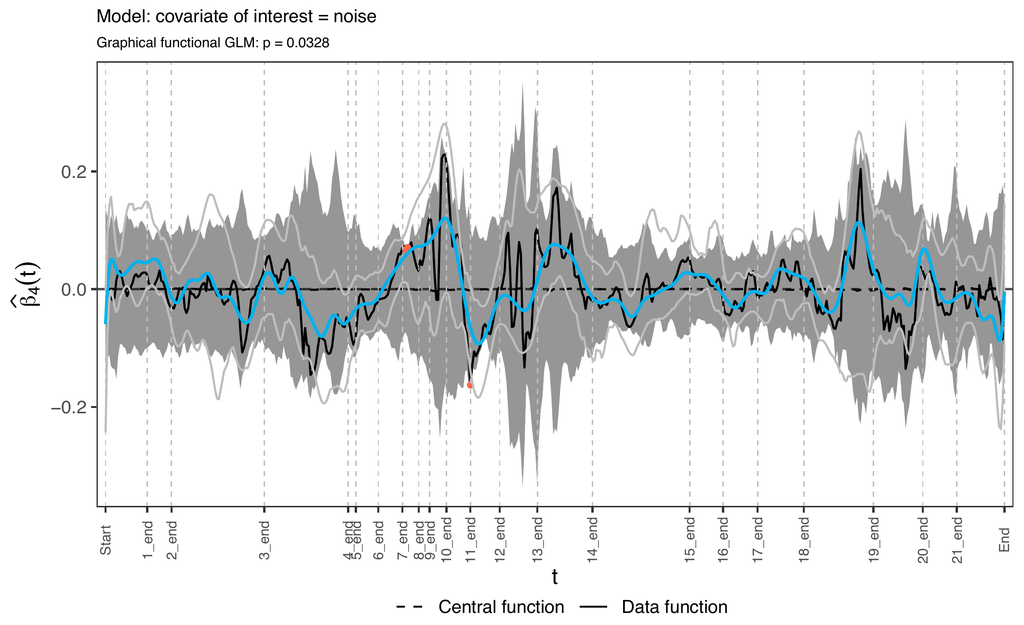

Graph for **Noise**

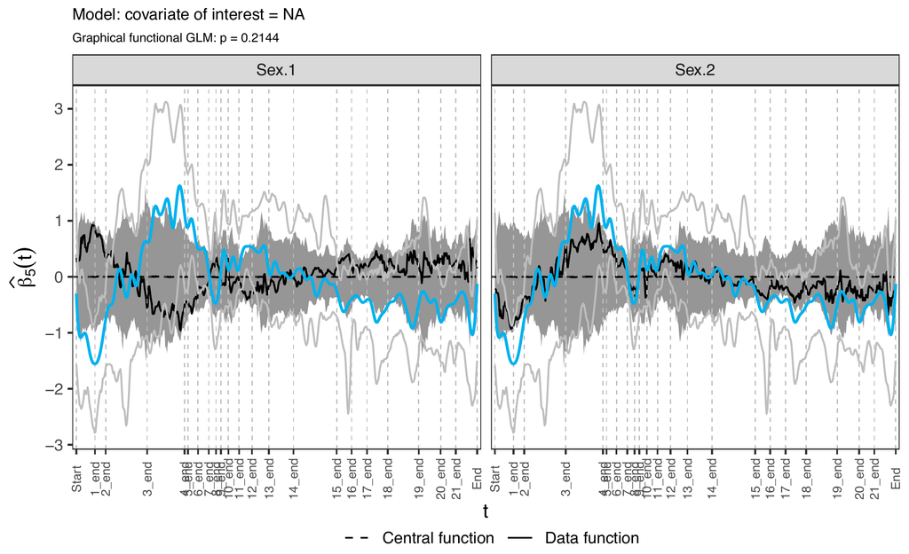

Graph for **Sex**

# 4 Conclusion

To sum up the functional analysis performed for Heart Rate and Electrodermal Activity, here are the key points of the process:

1. For each target functional variable (HR and EDA), we fit around 30 functional linear models.
2. For each functional model, we calculate a few numerical characteristics to assess the quality of the model fit and to be able to compare models.
3. From all models for HR and EDA, we filter only those that are significant ($p$-value ${}<0.05$) according to the *permutation $F$-test* (Section 1.4).
4. From the significant models for HR and EDA, we select a small number of models.
5. For the selected models, we assess the significance of each functional covariate separately using the *global envelope test* (Section 1.5).

To sum up the results of our analysis, here is a list of key findings:

- for modelling **HR**, we select 3 models (Section 2):
  - the covariate **slope** has a significant or near-significant effect on the value of heart rate (Section 2.1 – Section 2.2),
  - the covariate related to movement (**speed**) also has a significant effect on the value of heart rate (Section 2.1 – Section 2.3),
  - the covariate **noise** has a significant effect on the value of heart rate (Section 2.2),
  - we are able to interpret *where* the effects are significant (identify the time domain responsible for rejection),
  - the covariates of air pollution **PM2.5** and Sex have a non-significant effect on HR, but improves the quality of the overall fit (Section 2.3).
- for modelling **EDA**, we select 3 models (Section 3):
  - the covariate **wrist skin temperature (WST)** has a significant effect on EDA in all models (Section 3.1 – Section 3.3),
  - the covariate **speed** has a significant effect on EDA in all models (Section 3.1 – Section 3.3),
  - the covariate **noise** has a significant or a near-significant effect on the values of EDA (Section 3.2, Section 3.3),
  - again, we are able to interpret *where* the effect is significant (identify the time domain responsible for rejection),
  - the covariate **slope** has a significant effect on EDA in one model (Section 3.3).